# TFM 3

En este caso vamos a intentar predecir Total_OoS (uds de rotura de stock) en función de características de los productos.

## IMPORTACION DE DATOS, TRATAMIENTO DE NA'S Y OUTLIERS

```python
#Importamos librerías:

import numpy as np
import pandas as pd
import seaborn as sns
import matplotlib.pyplot as plt
import pyodbc
```

```python
#Cargamos los csv

# Conexión con MSSQL Server
server = 'DESKTOP-VUJ9ETK\SQLEXPRESS'
database = 'TFM_EnriqueRocho'

conn = pyodbc.connect('DRIVER={SQL Server};SERVER=' + server + ';DATABASE=' + database + ';Trusted_Connection=yes;')

# Query para seleccionar los datos de las tablas
query1 = 'SELECT * FROM all_tables'
query2 = 'SELECT * FROM Delivery_Route'
query3 = 'SELECT * FROM Sales_Rotura'

# Pasamos los resultados SQL a DataFrames
df_all_tables = pd.read_sql(query1, conn)
df_Delivery_Route = pd.read_sql(query2, conn)
df_Sales_Rotura = pd.read_sql(query3, conn)

# Cerramos la conexión
conn.close()

# Revisamos los datos de los Dataframes
print(df_all_tables.head())
print(df_Delivery_Route.head())
print(df_Sales_Rotura.head())
```

```
   Month Affiliated_Code Affiliated_NAME  POSTALCODE         poblacion  \
0      8         WU2uAAH     PALACIO-130       39195           Arnuero
1      3         WlMJAA1     GABRIEL-601        3001  Alacant-alicante
2      9         WkTfAAL      ESPAÑA-770       45700         Consuegra
3      6         WUpBAAX   PURÍSSIMA-122       43201              Reus
4      9         WUxTAAX    SERVANDA-106       11006             CAdiz

          provincia  Engage  Management_Cluster    Location   Tam_m2  \
0         Cantabria       1                   0  VACATIONAL     N.D.
1  Alicante/Alacant       2                   3        CITY     N.D.
2            Toledo       2                   2     VILLAGE     N.D.
3         Tarragona       3                   4         ANY  20-30m2
4             Cadiz       2                   4         ANY     N.D.

  Product_Code  SIZE Format  Cost_price  Sell_price  Margin  Total_Delivered  \
```

[output cut: 52 more lines]

```python
df_all_tables['provincia'].fillna('Desconocido', inplace=True)
df_all_tables['poblacion'].fillna('Desconocido', inplace=True)

df_Delivery_Route['provincia'].fillna('Desconocido', inplace=True)
df_Delivery_Route['poblacion'].fillna('Desconocido', inplace=True)

df_Delivery_Route['Delivery_DAY'] = pd.to_datetime(df_Delivery_Route['Delivery_DAY'])
df_Delivery_Route['Route_DAY'] = pd.to_datetime(df_Delivery_Route['Route_DAY'])

df_Sales_Rotura['Sales_DAY'] = pd.to_datetime(df_Sales_Rotura['Sales_DAY'])
df_Sales_Rotura['OoS_DAY'] = pd.to_datetime(df_Sales_Rotura['OoS_DAY'])

df_Sales_Rotura['provincia'].fillna('Desconocido', inplace=True)
df_Sales_Rotura['poblacion'].fillna('Desconocido', inplace=True)
```

```python
#Preparamos outliers

from scipy import stats

threshold = 2
outliers2 = df_all_tables[np.abs(stats.zscore(df_all_tables['Total_Delivered'])) > threshold]
```

```python
threshold = 2
outliers4 = df_all_tables[np.abs(stats.zscore(df_all_tables['Total_Sales'])) > threshold]
```

```python
outliers_indices = outliers2.index.union(outliers4.index)
df_all_tables_no_outliers = df_all_tables.drop(outliers_indices)
```

```python
df_all_tables_no_outliers  = df_all_tables_no_outliers[(df_all_tables_no_outliers ['Total_Delivered'] >= 0)
                                                       & (df_all_tables_no_outliers ['Total_Sales'] >= 0)]
```

```python
df_all_tables_no_outliers.columns
```

```
Index(['Month', 'Affiliated_Code', 'Affiliated_NAME', 'POSTALCODE',
       'poblacion', 'provincia', 'Engage', 'Management_Cluster', 'Location',
       'Tam_m2', 'Product_Code', 'SIZE', 'Format', 'Cost_price', 'Sell_price',
       'Margin', 'Total_Delivered', 'Total_Sales', 'Total_OoS'],
      dtype='object')
```

```python
threshold = 3
outliers6 = df_Sales_Rotura[np.abs(stats.zscore(df_Sales_Rotura['Sales_Uds'])) > threshold]

outlier_indices6 = outliers6.index

df_Sales_Rotura_no_outliers = df_Sales_Rotura.drop(outlier_indices6)
df_Sales_Rotura_no_outliers  = df_Sales_Rotura_no_outliers[(df_Sales_Rotura_no_outliers['Sales_Uds']>= 0)]
```

## PREPARACIÓN DE DATOS PARA LOS ALGORITMOS

En este caso como vamos a intentar obtener Total_OoS (uds de rotura de stock) en función de características de los productos, por lo que haremos drop de las columnas o variables que no hacen referencia a ese ámbito:

#### ELECCIÓN DE VARIABLES

```python
#Copiamos el dataframe para crear un df nuevo y haremos drop de columnas que no usaremos a priori.

df_product = df_all_tables_no_outliers.copy()

df_product = df_product.drop(['Affiliated_Code', 'Affiliated_NAME', 'POSTALCODE',
       'poblacion', 'provincia', 'Engage', 'Management_Cluster', 'Location',
       'Tam_m2'], axis=1)

df_product.head()
```

|  | Month | Product_Code | SIZE | Format | Cost_price | Sell_price | Margin | Total_Delivered | Total_Sales | Total_OoS |
| --- | --- | --- | --- | --- | --- | --- | --- | --- | --- | --- |
| 0 | 8 | Natu079 | 85 | ASL | 40.30 | 48.70 | 8.40 | 0 | 8 | 0 |
| 1 | 3 | Inte327 | 85 | ASL | 42.57 | 48.79 | 6.22 | 0 | 2 | 0 |
| 2 | 9 | Natu122 | 283 | ATA | 42.06 | 50.45 | 8.39 | 0 | 2 | 0 |
| 3 | 6 | Trad110 | 142 | ASL | 64.40 | 77.77 | 13.37 | 0 | 1 | 0 |
| 4 | 9 | Natu079 | 85 | ASL | 40.30 | 48.70 | 8.40 | 0 | 2 | 0 |

#### DUMMY VARIABLES

Creamos el df categórico, indicando las columnas que queremos transformar:

```python
# Trabajaremos con las siguientes columnas categóricas:
categorical_columns = ['Month','Product_Code', 'SIZE', 'Format']

df_product_cat = pd.get_dummies(df_product, columns=categorical_columns)
```

```python
df_product_cat.head()
```

|  | Cost_price | Sell_price | Margin | Total_Delivered | Total_Sales | Total_OoS | Month_3 | Month_4 | Month_5 | Month_6 | ... | SIZE_425 | SIZE_481 | SIZE_538 | SIZE_566 | SIZE_708 | SIZE_1132 | SIZE_1415 | Format_ASL | Format_ATA | Format_ETO |
| --- | --- | --- | --- | --- | --- | --- | --- | --- | --- | --- | --- | --- | --- | --- | --- | --- | --- | --- | --- | --- | --- |
| 0 | 40.30 | 48.70 | 8.40 | 0 | 8 | 0 | 0 | 0 | 0 | 0 | ... | 0 | 0 | 0 | 0 | 0 | 0 | 0 | 1 | 0 | 0 |
| 1 | 42.57 | 48.79 | 6.22 | 0 | 2 | 0 | 1 | 0 | 0 | 0 | ... | 0 | 0 | 0 | 0 | 0 | 0 | 0 | 1 | 0 | 0 |
| 2 | 42.06 | 50.45 | 8.39 | 0 | 2 | 0 | 0 | 0 | 0 | 0 | ... | 0 | 0 | 0 | 0 | 0 | 0 | 0 | 0 | 1 | 0 |
| 3 | 64.40 | 77.77 | 13.37 | 0 | 1 | 0 | 0 | 0 | 0 | 1 | ... | 0 | 0 | 0 | 0 | 0 | 0 | 0 | 1 | 0 | 0 |
| 4 | 40.30 | 48.70 | 8.40 | 0 | 2 | 0 | 0 | 0 | 0 | 0 | ... | 0 | 0 | 0 | 0 | 0 | 0 | 0 | 1 | 0 | 0 |

5 rows × 98 columns

#### SelectKBest

Usamos SelectKBest para revisar entre todas las nuevas obtenidas, cuales son las columnas que más impactan en Total_OoS

```python
#Revisamos las columnas que más impactan en Total_OoS:

from sklearn.feature_selection import SelectKBest, f_regression
import pandas as pd

# Separamos los datos en features (X) y la variable objetivo ('Total_OoS')
X = df_product_cat.drop(columns=['Total_OoS'])  # Features
y = df_product_cat['Total_OoS']  # Variable Objetivo

# Inicializamos SelectKBest con la scoring function (f_regression para problemas de regresion)
selector = SelectKBest(score_func=f_regression, k=10)

# Ajustamos el selector a los datos
X_new = selector.fit_transform(X, y)

# Obtenemos las columnas seleccionadas
selected_columns = X.columns[selector.get_support()]

# Creamos un df con las columnas seleccionadas
selected_features_df = pd.DataFrame(X_new, columns=selected_columns)

# Mostramos las features más importantes
print("Selected Features:")
print(selected_features_df.head())
```

```
Selected Features:
   Total_Delivered  Total_Sales  Month_10  Product_Code_Inte615  \
0              0.0          8.0       0.0                   0.0
1              0.0          2.0       0.0                   0.0
2              0.0          2.0       0.0                   0.0
3              0.0          1.0       0.0                   0.0
4              0.0          2.0       0.0                   0.0

   Product_Code_Natu122  SIZE_85  SIZE_213  SIZE_283  SIZE_1132  Format_ATA
0                   0.0      1.0       0.0       0.0        0.0         0.0
1                   0.0      1.0       0.0       0.0        0.0         0.0
2                   1.0      0.0       0.0       1.0        0.0         1.0
3                   0.0      0.0       0.0       0.0        0.0         0.0
4                   0.0      1.0       0.0       0.0        0.0         0.0
```

Primero usaremos algunas de estas columnas, además de algunas más relacionadas con Producto en un nuevo subset para ver qué resultados obtenemos.

```python
#Creamos el nuevo subset:

specified_columns2 = ['Total_OoS','Cost_price', 'Sell_price','Month_3', 'Month_4', 'Month_5', 'Month_6',
                    'Month_7', 'Month_8', 'Month_9', 'Month_10', 'Month_3', 'Month_4', 'Month_5', 'Month_6', 'Month_7',
       'Month_8', 'Month_9', 'Month_10',
       'Product_Code_Natu408','Product_Code_Dome206','Product_Code_Dome427','Product_Code_Natu079','Product_Code_Brit627',
       'Product_Code_Natu969','Product_Code_Dome164', 'Product_Code_Natu122','Product_Code_Brit700', 'Product_Code_Dome213',
       'Product_Code_Inte404','Product_Code_Dome363','Product_Code_Dome762','Product_Code_Dome459','Product_Code_Natu723',
       'Product_Code_Inte327', 'Product_Code_Dome615','Product_Code_Dome797','Product_Code_Dome527','Product_Code_Brit555',
       'Product_Code_Natu461','Product_Code_Dome104',
       'SIZE_85', 'SIZE_142', 'SIZE_190','SIZE_317','SIZE_283','SIZE_125','SIZE_114', 'SIZE_481',
       'Format_ASL', 'Format_ATA',
       'Format_ETO']

df_product_oos = df_product_cat[specified_columns2].copy()

df_product_oos.head()
```

|  | Total_OoS | Cost_price | Sell_price | Month_3 | Month_4 | Month_5 | Month_6 | Month_7 | Month_8 | Month_9 | ... | SIZE_142 | SIZE_190 | SIZE_317 | SIZE_283 | SIZE_125 | SIZE_114 | SIZE_481 | Format_ASL | Format_ATA | Format_ETO |
| --- | --- | --- | --- | --- | --- | --- | --- | --- | --- | --- | --- | --- | --- | --- | --- | --- | --- | --- | --- | --- | --- |
| 0 | 0 | 40.30 | 48.70 | 0 | 0 | 0 | 0 | 0 | 1 | 0 | ... | 0 | 0 | 0 | 0 | 0 | 0 | 0 | 1 | 0 | 0 |
| 1 | 0 | 42.57 | 48.79 | 1 | 0 | 0 | 0 | 0 | 0 | 0 | ... | 0 | 0 | 0 | 0 | 0 | 0 | 0 | 1 | 0 | 0 |
| 2 | 0 | 42.06 | 50.45 | 0 | 0 | 0 | 0 | 0 | 0 | 1 | ... | 0 | 0 | 0 | 1 | 0 | 0 | 0 | 0 | 1 | 0 |
| 3 | 0 | 64.40 | 77.77 | 0 | 0 | 0 | 1 | 0 | 0 | 0 | ... | 1 | 0 | 0 | 0 | 0 | 0 | 0 | 1 | 0 | 0 |
| 4 | 0 | 40.30 | 48.70 | 0 | 0 | 0 | 0 | 0 | 0 | 1 | ... | 0 | 0 | 0 | 0 | 0 | 0 | 0 | 1 | 0 | 0 |

5 rows × 52 columns

```python
df_product_oos.columns
```

```
Index(['Total_OoS', 'Cost_price', 'Sell_price', 'Month_3', 'Month_4',
       'Month_5', 'Month_6', 'Month_7', 'Month_8', 'Month_9', 'Month_10',
       'Month_3', 'Month_4', 'Month_5', 'Month_6', 'Month_7', 'Month_8',
       'Month_9', 'Month_10', 'Product_Code_Natu408', 'Product_Code_Dome206',
       'Product_Code_Dome427', 'Product_Code_Natu079', 'Product_Code_Brit627',
       'Product_Code_Natu969', 'Product_Code_Dome164', 'Product_Code_Natu122',
       'Product_Code_Brit700', 'Product_Code_Dome213', 'Product_Code_Inte404',
       'Product_Code_Dome363', 'Product_Code_Dome762', 'Product_Code_Dome459',
       'Product_Code_Natu723', 'Product_Code_Inte327', 'Product_Code_Dome615',
       'Product_Code_Dome797', 'Product_Code_Dome527', 'Product_Code_Brit555',
       'Product_Code_Natu461', 'Product_Code_Dome104', 'SIZE_85', 'SIZE_142',
       'SIZE_190', 'SIZE_317', 'SIZE_283', 'SIZE_125', 'SIZE_114', 'SIZE_481',
       'Format_ASL', 'Format_ATA', 'Format_ETO'],
      dtype='object')
```

La idea inicial era realizar un pca para reducir la dimensionalidad, hacer clustering y aplicar una regresión lineal una vez optimizado todo.

Estamos excluyendo la target variable Total_OoS ya que si la incluimos con el resto de features puede condicionar el peso del clustering.

Revisamos de nuevo la cantidad óptima de clusters

Es posible además que sea mucho más valioso aplicar clustering sobre columnas más concretas.

Aunque este nuevo análisis no nos dará información de qué productos estarán fuera de stock en un determinado mes, sí que nos servirá para saber qué grupos de productos se comportan de manera similar en cuanto a rotura para determinados meses.

#### StandardScaler, Clustering y PCA

```python
from sklearn.preprocessing import StandardScaler
from sklearn.decomposition import PCA
from sklearn.cluster import KMeans
import pandas as pd

# Separamos 'Total_OoS' como variable objetivo
y = df_product_oos['Total_OoS']

# Datos que usaremos en clustering y PCA
X_for_clustering = df_product_oos.drop(columns=['Total_OoS'])  # Data for clustering

# Escalamos las variables numéricas
numerical_columns = ['Cost_price', 'Sell_price']
scaler_for_pca = StandardScaler()
```

```python
X_for_pca_scaled = X_for_clustering.copy()
X_for_pca_scaled[numerical_columns] = scaler_for_pca.fit_transform(X_for_clustering[numerical_columns])


# Realizamos K-means clustering para 3 clusters
kmeans = KMeans(n_clusters=3, random_state=42)
clusters = kmeans.fit_predict(X_for_clustering)

# Add cluster labels to the data
X_for_clustering['Cluster'] = clusters
```

Revisamos el num óptimo de Clusters:

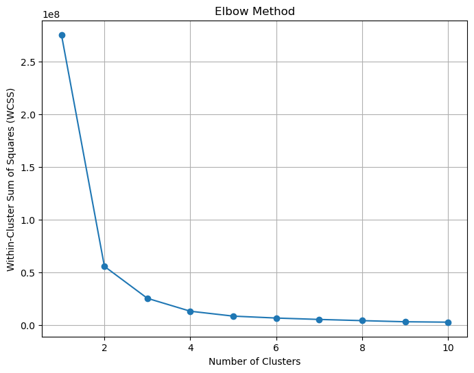

```python
wcss = []

#Num máximo de clusters a testear:
max_clusters = 10
for i in range(1, max_clusters + 1):
    kmeans = KMeans(n_clusters=i, random_state=42)
    kmeans.fit(X_for_clustering)
    wcss.append(kmeans.inertia_)

# Plot de inertia:
plt.figure(figsize=(8, 6))
plt.plot(range(1, max_clusters + 1), wcss, marker='o')
plt.title('Elbow Method')
plt.xlabel('Number of Clusters')
plt.ylabel('Within-Cluster Sum of Squares (WCSS)')
plt.grid(True)
plt.show()
```

El num óptimo de clusters parece ser 2-3 según lo que veremos en el siguiente plot de inertia. Mantendremos 3 sobretodo para tener una visualización más segmentada.

Además revisamos el num adecuado de componentes PCA:

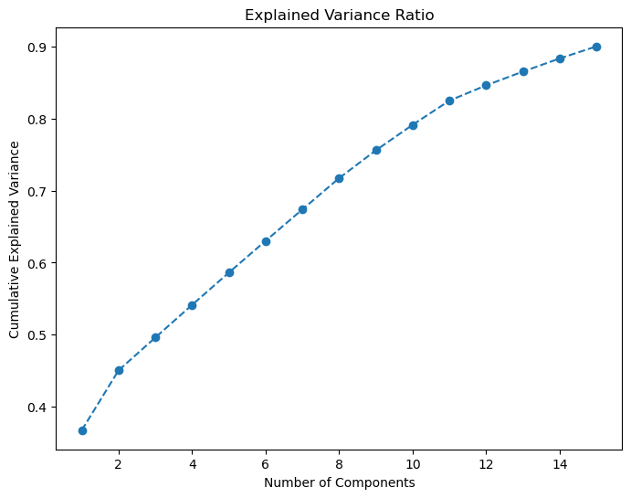

```python
# Ajuste del num máximo de componentes
optimal_components =  15
pca = PCA(n_components=optimal_components)
pca_result = pca.fit_transform(X_for_pca_scaled)

# Plot
plt.figure(figsize=(8, 6))
plt.plot(range(1, len(pca.explained_variance_ratio_) + 1), pca.explained_variance_ratio_.cumsum(), marker='o', linestyle='--')
plt.xlabel('Number of Components')
plt.ylabel('Cumulative Explained Variance')
plt.title('Explained Variance Ratio')
plt.show()
```

Con 11 componentes se explica más del 80% de la varianza, por lo que usaremos 11 como componentes óptimos.

```python
from sklearn.decomposition import PCA

# Applicamos de nuevo PCA con los componentes óptimos
optimal_components = 11
pca = PCA(n_components=optimal_components)
pca_result = pca.fit_transform(X_for_pca_scaled)

# DF para los componentes PCACreate a DataFrame with PCA components
df_pca = pd.DataFrame(data=pca_result, columns=[f'PCA_{i+1}' for i in range(optimal_components)], index=X_for_clustering.index)

# Concatenamos 'df_pca' con los datos de cluster
X_clustered = pd.concat([df_pca, X_for_clustering['Cluster']], axis=1)

# Concatenamos con 'Total_OoS'
df_processed = pd.concat([X_clustered, y], axis=1)
```

```python
df_processed.columns
```

```
Index(['PCA_1', 'PCA_2', 'PCA_3', 'PCA_4', 'PCA_5', 'PCA_6', 'PCA_7', 'PCA_8',
       'PCA_9', 'PCA_10', 'PCA_11', 'Cluster', 'Total_OoS'],
      dtype='object')
```

```python
#Revisamos Nan por posibles errores de concat en la creación de df_processed

df_processed.isnull().sum()
```

```
PCA_1        0
PCA_2        0
PCA_3        0
PCA_4        0
PCA_5        0
PCA_6        0
PCA_7        0
PCA_8        0
PCA_9        0
PCA_10       0
PCA_11       0
Cluster      0
Total_OoS    0
dtype: int64
```

## APLICACIÓN DE ALGORITMOS

#### Regresión Lineal

Aplicaremos primero una regresión lineal para ver el comportamiento del dataset obtenido después de clustering, PCA y StandardScaler con la variable objetivo Total_OoS.

```python
from sklearn.linear_model import LinearRegression
from sklearn.model_selection import train_test_split
from sklearn.metrics import mean_squared_error, r2_score

# Separamos las features de la variable objetivo
X2 = df_processed.drop(columns=['Total_OoS'])
y2 = df_processed['Total_OoS']

# Obtenemos los sets testing y training
X_train2, X_test2, y_train2, y_test2 = train_test_split(X2, y2, test_size=0.2, random_state=42)

# Inicializamos el modelo
reg = LinearRegression()
reg.fit(X_train2, y_train2)

# Predecimos sobre el set de testing
y_pred2 = reg.predict(X_test2)

# Evaluamos el modelo
mse = mean_squared_error(y_test2, y_pred2)
r2 = r2_score(y_test2, y_pred2)

print(f"Mean Squared Error: {mse}")
print(f"R-squared Score: {r2}")
```

```
Mean Squared Error: 8.374584330562904
R-squared Score: 0.028566769130333736
```

Como vemos el MSE es bastante alto y el R2 explica una porción muy pequeña de la varianza de Total_OoS (2,9%).Podemos hacer visualizaciones para obtener más información.

Realizamos primero una visualización 3D de clustering de los 3 primeros componentes

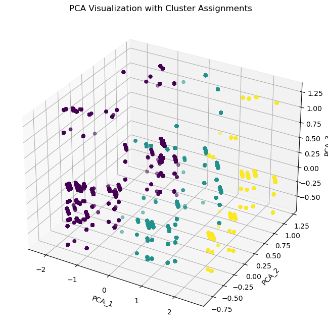

```python
# Visualización 3 primeros componentes.
from mpl_toolkits.mplot3d import Axes3D

fig = plt.figure(figsize=(10, 8))
ax = fig.add_subplot(111, projection='3d')
ax.scatter(df_pca['PCA_1'], df_pca['PCA_2'], df_pca['PCA_3'], c=X_for_clustering['Cluster'], cmap='viridis', alpha=0.5)
ax.set_xlabel('PCA_1')
ax.set_ylabel('PCA_2')
ax.set_zlabel('PCA_3')
ax.set_title('PCA Visualization with Cluster Assignments')
plt.show()
```

Visualizamos los resultados de Predicción Total_OoS contra los valores predichos:

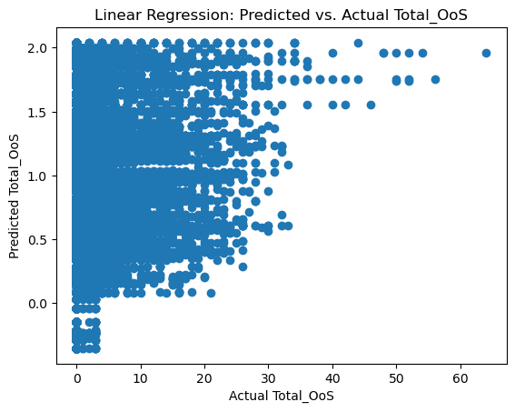

```python
plt.scatter(y_test2, y_pred2)
plt.title('Linear Regression: Predicted vs. Actual Total_OoS')
plt.xlabel('Actual Total_OoS')
plt.ylabel('Predicted Total_OoS')
plt.show()
```

En general se están prediciendo valores muy bajos, y esto puede ser debido al gran peso del valor 0 para Total_OoS, ya que hemos visto que hay muchísimos valores 0 y pocos que no son 0. Esto puede condicionar las predicciones de los modelos, como puede ser este caso.

Igualmente vamos a intentar aplicar otros modelos.

#### Random Forest

Aplicaremos un random forest haciendo una selección de las 10 features con más peso sobre la variable objetivo Total_OoS para intentar mejorar la precisión del modelo.

```python
from sklearn.ensemble import RandomForestRegressor

# Inicializamos el modelo
forest = RandomForestRegressor(random_state=42)

# Ajustamos el modelo
forest.fit(X_train2, y_train2)

# Revisamos la importancia de las features
feature_importances = forest.feature_importances_

# Creamos un df con la importancia de las features y las columnas correspondientes
feature_importance_df = pd.DataFrame({'Feature': X2.columns, 'Importance': feature_importances})

# Ordenamos por importancia
feature_importance_df = feature_importance_df.sort_values(by='Importance', ascending=False)

# Seleccionamos las 10 features más importantes
top_features = feature_importance_df.head(10)['Feature'].tolist()

# Vovemos a entrenar el modelo con los features seleccionados
reg = LinearRegression()
reg.fit(X_train2[top_features], y_train2)

# Predecimos sobre el test set con los features seleccionados
y_pred3 = reg.predict(X_test2[top_features])

# Evaluamos el modelo
mse = mean_squared_error(y_test2, y_pred3)
r2 = r2_score(y_test2, y_pred3)

print(f"Mean Squared Error with selected features: {mse}")
print(f"R-squared Score with selected features: {r2}")
```

```
Mean Squared Error with selected features: 8.375288158280846
R-squared Score with selected features: 0.028485126674179795
```

No obtenemos una mejora con este método.

#### GradientBoostingRegressor

Antes de realizar más cambios, vamos a intentarlo con otro modelom Gradient Boosting Regressor.

```python
from sklearn.ensemble import GradientBoostingRegressor

# Inicializamos el modelo
grad_boost = GradientBoostingRegressor(random_state=42)

# Ajustamos el modelo
grad_boost.fit(X_train2, y_train2)

# Predecimos sobre el test set
y_pred4 = grad_boost.predict(X_test2)

# Evaluamos el modelo
mse = mean_squared_error(y_test2, y_pred4)
r2 = r2_score(y_test2, y_pred4)

print(f"Mean Squared Error with Gradient Boosting: {mse}")
print(f"R-squared Score with Gradient Boosting: {r2}")
```

```
Mean Squared Error with Gradient Boosting: 7.977937779180815
R-squared Score with Gradient Boosting: 0.07457689043464866
```

Como vemos en este caso se han mejorado los resultados, pero no es una mejora sensible que nos permita decidirnos este modelo.

#### Mejoras en PCA

Vamos a revisar los diferentes componentes PCA y su peso con respecto a la variable objetivo:

```python
from sklearn.feature_selection import SelectKBest, f_regression

selector = SelectKBest(score_func=f_regression, k='all')
selector.fit(df_pca, y2)

# Conseguimos puntuaciones y p-values para cada feature
feature_scores = pd.DataFrame({'Feature': df_pca.columns, 'Score': selector.scores_, 'p-value': selector.pvalues_})
feature_scores.sort_values(by='Score', ascending=False, inplace=True)
print(feature_scores)
```

```
   Feature        Score        p-value
8    PCA_9  7544.566250   0.000000e+00
1    PCA_2  2177.990023   0.000000e+00
6    PCA_7   731.655330  5.676718e-161
4    PCA_5   246.828914   1.331423e-55
2    PCA_3   156.298044   7.413203e-36
3    PCA_4    63.782282   1.393635e-15
10  PCA_11    62.448274   2.743016e-15
9   PCA_10    35.520314   2.526383e-09
0    PCA_1    24.434632   7.690874e-07
7    PCA_8    23.696738   1.128212e-06
5    PCA_6     8.271974   4.026407e-03
```

Vamos a intentar aplicar una regresión lineal a partir de los componentes PCA con mayor peso sobre la variable objetivo.

```python
# Usamos los componentes top 5 según los Score obtenidos
k = 5
top_components = feature_scores['Feature'][:k].tolist()

# Seleccionamos los top componentes
selected_pca_components = df_pca[top_components]

# Dividimos los datos en training y tests
X_train3, X_test3, y_train3, y_test3 = train_test_split(selected_pca_components, y2, test_size=0.2, random_state=42)

# Inicialiamos la regresión lineal
regression_model = LinearRegression()

# Ajustamos el modelo
regression_model.fit(X_train3, y_train3)

# Hacemos predicciones
predictions3 = regression_model.predict(X_test3)

# Valoramos con MSE y R2
mse = mean_squared_error(y_test3, predictions3)
r2 = r2_score(y_test3, predictions3)

print(f"Mean Squared Error (MSE): {mse}")
print(f"R-squared (R2) Score: {r2}")
```

```
Mean Squared Error (MSE): 8.381405324885703
R-squared (R2) Score: 0.027775548898834157
```

Los resultados con mejores componentes PCA son bajos también, por lo que parece que más allá del algoritmo escogido parece un problema de elección de features, o tal vez de peso del valor 0 en Total_OoS.

#### Elección de nuevas variables/features

Revisamos de nuevo la importancia de los features con respecto a Total_OoS:

```python
from sklearn.feature_selection import SelectKBest, f_regression

# Separamos los datos en features (X) y la variable objetivo ('Total_OoS')
X3 = df_product_cat.drop(columns=['Total_OoS'])  # Features
y3 = df_product_cat['Total_OoS']  # Variable Objetivo

# Inicializamos SelectKBest con la scoring function (f_regression para problemas de regresion)
selector = SelectKBest(score_func=f_regression, k=10)

# Ajustamos el selector a los datos
X_new = selector.fit_transform(X3, y3)

# Obtenemos las columnas seleccionadas
selected_columns = X3.columns[selector.get_support()]

# Creamos un df con las columnas seleccionadas
selected_features_df = pd.DataFrame(X_new, columns=selected_columns)

# Mostramos las features más importantes
print("Selected Features:")
print(selected_features_df.head())
```

```
Selected Features:
   Total_Delivered  Total_Sales  Month_10  Product_Code_Inte615  \
0              0.0          8.0       0.0                   0.0
1              0.0          2.0       0.0                   0.0
2              0.0          2.0       0.0                   0.0
3              0.0          1.0       0.0                   0.0
4              0.0          2.0       0.0                   0.0

   Product_Code_Natu122  SIZE_85  SIZE_213  SIZE_283  SIZE_1132  Format_ATA
0                   0.0      1.0       0.0       0.0        0.0         0.0
1                   0.0      1.0       0.0       0.0        0.0         0.0
2                   1.0      0.0       0.0       1.0        0.0         1.0
3                   0.0      0.0       0.0       0.0        0.0         0.0
4                   0.0      1.0       0.0       0.0        0.0         0.0
```

También revisamos las variables que más impactan en Total_OoS usando un random forest classifier:

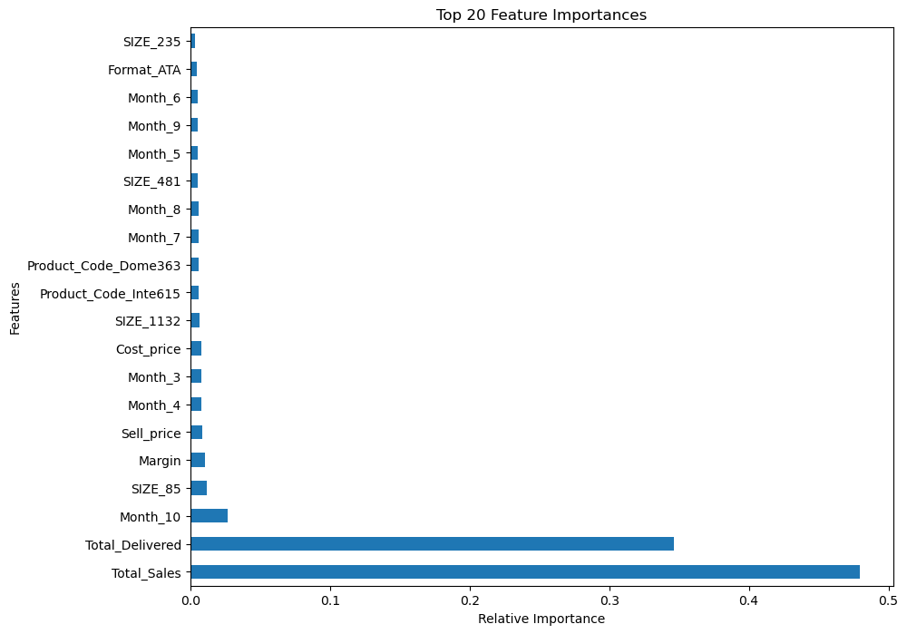

```python
from sklearn.ensemble import RandomForestClassifier
import matplotlib.pyplot as plt

# Inicializamos RF
rf = RandomForestClassifier(n_estimators=100, random_state=42)

# Ajuste de modelo
rf.fit(X3, y3)

# Features por importancia
feature_importances = pd.Series(rf.feature_importances_, index=X3.columns)
feature_importances = feature_importances.sort_values(ascending=False)

# Plot
plt.figure(figsize=(10, 8))
feature_importances.head(20).plot(kind='barh')
plt.title('Top 20 Feature Importances')
plt.xlabel('Relative Importance')
plt.ylabel('Features')
plt.show()
```

Vemos que Total_Delivered y Total_Sales tienen un gran impacto en Total_OoS, lo que es lógico ya que más ventas pueden llevar a roturas de stock, y más entregas hemos visto que podían suponer más ventas.

Se consideró quitar Total_Sales o Total_Delivered de los posteriores estudios de modelos, pero la precisión en los mismos caía drásticamente para cualquiera de esas dos columnas (entorno a un 10-25% de precisión MSE como máximo).

Hemos dejado otras features como algunos Product_Code importantes, los meses, Cost_price, Sell_Price, Margin y Size para poder ampliar las predicciones a más campos, y también porque perdíamos algo de precisión sin alguno de ellos.

```python
duplicate_columns = X3.columns[X3.columns.duplicated()]
print(duplicate_columns)
```

```
Index([], dtype='object')
```

```python
X4 = df_product_cat[['Total_Sales', 'Total_Delivered', 'Cost_price', 'Sell_price', 'Margin',
                              'Month_3', 'Month_4', 'Month_5', 'Month_6', 'Month_7', 'Month_8', 'Month_9', 'Month_10',
                              'Product_Code_Natu408', 'Product_Code_Dome206', 'Product_Code_Dome427',
                              'Product_Code_Natu079', 'Product_Code_Brit627', 'Product_Code_Natu969',
                              'Product_Code_Dome164', 'Product_Code_Natu122', 'Product_Code_Brit700',
                              'Product_Code_Dome213', 'Product_Code_Inte404', 'Product_Code_Dome363',
                              'Product_Code_Dome762', 'Product_Code_Dome459', 'Product_Code_Natu723',
                              'Product_Code_Inte327', 'Product_Code_Dome615', 'Product_Code_Dome797',
                              'Product_Code_Dome527', 'Product_Code_Brit555', 'Product_Code_Natu461',
                              'Product_Code_Dome104',
                              'SIZE_85', 'SIZE_142', 'SIZE_190', 'SIZE_317', 'SIZE_283', 'SIZE_125', 'SIZE_114', 'SIZE_481']].copy()

y4 = df_product_cat[['Total_OoS']].copy()
```

```python
duplicate_columns = X4.columns[X4.columns.duplicated()]
print(duplicate_columns)
```

```
Index([], dtype='object')
```

#### Decission Tree

Iniciamos un modelo de árbol de decisión, escalaremos las variables numéricas.

```python
from sklearn.tree import DecisionTreeRegressor

X_train4, X_test4, y_train4, y_test4 = train_test_split(X4, y4, test_size=0.2, random_state=42)

# Extraemos las columnas numéricas
numerical_columns = ['Total_Sales','Cost_price', 'Sell_price','Margin']

# Escalamos las variables numéricas
scaler = StandardScaler()
X_train4[numerical_columns] = scaler.fit_transform(X_train4[numerical_columns])
X_test4[numerical_columns] = scaler.transform(X_test4[numerical_columns])

# Iniciamos el modelo
decision_tree = DecisionTreeRegressor(random_state=42)

# Ajustamos el modelo a los training sets
decision_tree.fit(X_train4, y_train4)

# Hacemos predicciones
tree_preds = decision_tree.predict(X_test4)

# Evaluamos el modelo
mse = mean_squared_error(y_test4, tree_preds)
print(f"Decision Tree MSE: {mse}")

r2 = r2_score(y_test4, tree_preds)
print(f"Decision Tree R-squared Score {r2}")
```

```
Decision Tree MSE: 5.189356056326031
Decision Tree R-squared Score 0.3980461929874646
```

#### Resampling y nuevo Decision Tree

Al haber un gran peso de los valores 0 en Total_OoS esto puede estar impactando en la predicción, por lo que vamos a intentar realizar un resampling para corregir esta tendencia y aplicar un modelo decision tree.

Este resampling intenta compensar el peso de los valores para que el modelo no se vea condicionado por el valor 0.

```python
from imblearn.over_sampling import RandomOverSampler
from imblearn.under_sampling import RandomUnderSampler
from imblearn.pipeline import Pipeline

# Definimos la estrategia de resampling con oversampling para valores que no son 0 y undersample para valores 0
resampling_strategy = [('over', RandomOverSampler()), ('under', RandomUnderSampler())]

# Creamos un pipeline de resampling
resampling_pipeline = Pipeline(steps=resampling_strategy)

# Ajustamos y aplicamos la estrategia de resampling en los datos de entrenamiento
X_train_resampled4, y_train_resampled4 = resampling_pipeline.fit_resample(X_train4, y_train4)
```

En este caso aplicaremos un clasificador Decisión Tree usando los sets sobre los que hemos aplicado el resampling.

```python
from sklearn.tree import DecisionTreeClassifier
from sklearn.metrics import classification_report
from sklearn.metrics import precision_score

# Iniciamos el Decision Tree classifier
clf = DecisionTreeClassifier(random_state=42)

# Ajustamos
clf.fit(X_train_resampled4, y_train_resampled4)

# Hacemos las predicciones en el test set
y_pred4 = clf.predict(X_test4)

# Revisamos un classification_report
print(classification_report(y_test4, y_pred4))

# Calculams la precision
precision = precision_score(y_test4, y_pred4, average='weighted')
print(f"Precision: {precision}")
```

```
              precision    recall  f1-score   support

           0       0.96      0.62      0.76     63252
           1       0.04      0.10      0.06      2102
           2       0.03      0.06      0.04      1347
           3       0.05      0.19      0.08      1011
           4       0.02      0.05      0.02       691
           5       0.01      0.04      0.02       476
           6       0.02      0.07      0.03       468
           7       0.01      0.04      0.02       340
           8       0.01      0.05      0.02       311
           9       0.01      0.06      0.02       209
          10       0.01      0.05      0.02       206
          11       0.01      0.03      0.01       153
          12       0.00      0.02      0.01       148
```

[output cut: 45 more lines]

Para los modelos de clasificación tenemos unas métricas distintas a los modelos de regresión.

Por ejemplo hemos utilizado classification_report por un lado, que incluye las siguientes métricas:

Precisión: Indica la proporción de instancias predichas correctamente entre las instancias predichas para cada clase. En este caso la precisión es baja, por lo que el modelo tiene a generar muchos falsos positivos.

Recall: proporción de las instancias predichas correctamente entre las instancias reales de cada clase. El Recall is bajo también lo que indica que el modelo tiene problemas para identificar correctamente las instancias de esas clases.

F1-score: Meda harmónica de precisión y recall, proporcionando equilibrio entre las dos métricas. Es bajo para casi todas las clases, indicando un funcionamiento pobre en general para precisión y recall.

Support: Indica el número de samples para cada clase. La clase '0' tiene muchos más samples que el resto de clases.

En conclusión, el modelo parece predecir bastante bien la clase mayoritaria 0, pero no para el resto dado el gran desequilibrio entre clases.

Hemos utilizado además una métrica de precisión que nos ha dado un 84% de precisión, lo que no se corresponde con lo obtenido con classification_report.

La aparente discrepancia entre la puntuación de precisión y el report de clasificación puede deberse a:

Metodología de Weighting: la media weighting en precision_score y en classification_report puede usar diferentes métodos para calcular la media weighted, posiblemente considerando la distribución de clases o de pesos de samples de manera diferente.

Normalización: el calculo puede realizarse mediante el número de samples entre otros factores, llevando a diferencias entre las medias de weight.

Revisamos además una gráfica para ver la correspondencia entre valores reales y predichos.

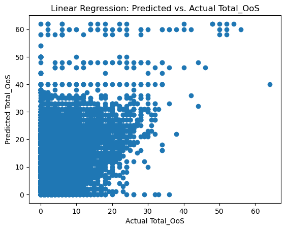

```python
plt.scatter(y_test4, y_pred4)
plt.title('Linear Regression: Predicted vs. Actual Total_OoS')
plt.xlabel('Actual Total_OoS')
plt.ylabel('Predicted Total_OoS')
plt.show()
```

Vemos que se están prediciendo valores más altos, lo que quiere decir que el resampling en ese sentido está funcionando y teniendo en cuenta valores más altos. Sin embargo los valores predichos más altos no se corresponden con los reales.

Aunque se acumulan mucho más los valores entorno a la diagonal donde deberían coincidir Actual y Predicted, vemos que la precisión no es muy alta sobretodo a partir de valores predicted más altos de 35, por lo que parece que al modelo le cuesta más predecir valores en general altos.

Utilizamos diferentes modelos para intentar obtener mejores resultados.

#### GaussianNB

```python
from sklearn.naive_bayes import GaussianNB
from sklearn.metrics import accuracy_score, classification_report

# Iniciamos el modelo
naive_bayes = GaussianNB()

# Ajustamos el modelo
naive_bayes.fit(X_train_resampled4, y_train_resampled4)

# Hacemos predicciones
nb_preds = naive_bayes.predict(X_test4)

# Evaluamos el modelo
accuracy = accuracy_score(y_test4, nb_preds)
print(f"Gaussian Naive Bayes Accuracy: {accuracy}")
print(classification_report(y_test4, nb_preds))
```

```
Gaussian Naive Bayes Accuracy: 0.06994688985902177
              precision    recall  f1-score   support

           0       0.98      0.07      0.14     63252
           1       0.03      0.12      0.05      2102
           2       0.00      0.00      0.00      1347
           3       0.03      0.14      0.05      1011
           4       0.00      0.00      0.00       691
           5       0.00      0.01      0.01       476
           6       0.13      0.04      0.07       468
           7       0.00      0.00      0.00       340
           8       0.00      0.00      0.00       311
           9       0.00      0.01      0.01       209
          10       0.00      0.00      0.00       206
          11       0.00      0.00      0.00       153
```

[output cut: 44 more lines]

Con GaussianNB la precisión es también baja.

#### SVM

Se entrena también un modelo más complejo como SVM, donde se ha tenido que entrenar el modelo en base a una pequeña porción de los datos para poder implementarlo sin incidencias en su ejecución (solo un 0,03 del total de datos).

```python
from sklearn.svm import SVC
from sklearn.metrics import classification_report, precision_score
from sklearn.preprocessing import StandardScaler
from sklearn.model_selection import train_test_split
from imblearn.over_sampling import RandomOverSampler
from imblearn.under_sampling import RandomUnderSampler
from imblearn.pipeline import Pipeline

# Seleccionamos las columnas
specified_columns3 = df_product_cat[['Total_OoS','Total_Sales', 'Total_Delivered', 'Cost_price', 'Sell_price', 'Margin',
                              'Month_3', 'Month_4', 'Month_5', 'Month_6', 'Month_7', 'Month_8', 'Month_9', 'Month_10',
                              'Product_Code_Natu408', 'Product_Code_Dome206', 'Product_Code_Dome427',
                              'Product_Code_Natu079', 'Product_Code_Brit627', 'Product_Code_Natu969',
                              'Product_Code_Dome164', 'Product_Code_Natu122', 'Product_Code_Brit700',
                              'Product_Code_Dome213', 'Product_Code_Inte404', 'Product_Code_Dome363',
                              'Product_Code_Dome762', 'Product_Code_Dome459', 'Product_Code_Natu723',
                              'Product_Code_Inte327', 'Product_Code_Dome615', 'Product_Code_Dome797',
                              'Product_Code_Dome527', 'Product_Code_Brit555', 'Product_Code_Natu461',
                              'Product_Code_Dome104',
                              'SIZE_85', 'SIZE_142', 'SIZE_190', 'SIZE_317', 'SIZE_283', 'SIZE_125', 'SIZE_114', 'SIZE_481']].copy()
```

```python
specified_columns3.head()
```

|  | Total_OoS | Total_Sales | Total_Delivered | Cost_price | Sell_price | Margin | Month_3 | Month_4 | Month_5 | Month_6 | ... | Product_Code_Natu461 | Product_Code_Dome104 | SIZE_85 | SIZE_142 | SIZE_190 | SIZE_317 | SIZE_283 | SIZE_125 | SIZE_114 | SIZE_481 |
| --- | --- | --- | --- | --- | --- | --- | --- | --- | --- | --- | --- | --- | --- | --- | --- | --- | --- | --- | --- | --- | --- |
| 0 | 0 | 8 | 0 | 40.30 | 48.70 | 8.40 | 0 | 0 | 0 | 0 | ... | 0 | 0 | 1 | 0 | 0 | 0 | 0 | 0 | 0 | 0 |
| 1 | 0 | 2 | 0 | 42.57 | 48.79 | 6.22 | 1 | 0 | 0 | 0 | ... | 0 | 0 | 1 | 0 | 0 | 0 | 0 | 0 | 0 | 0 |
| 2 | 0 | 2 | 0 | 42.06 | 50.45 | 8.39 | 0 | 0 | 0 | 0 | ... | 0 | 0 | 0 | 0 | 0 | 0 | 1 | 0 | 0 | 0 |
| 3 | 0 | 1 | 0 | 64.40 | 77.77 | 13.37 | 0 | 0 | 0 | 1 | ... | 0 | 0 | 0 | 1 | 0 | 0 | 0 | 0 | 0 | 0 |
| 4 | 0 | 2 | 0 | 40.30 | 48.70 | 8.40 | 0 | 0 | 0 | 0 | ... | 0 | 0 | 1 | 0 | 0 | 0 | 0 | 0 | 0 | 0 |

5 rows × 44 columns

```python
# Se realiza sample de los datos
sampled_data = specified_columns3.sample(frac=0.03, random_state=42)
```

```python
sampled_data.head()
```

|  | Total_OoS | Total_Sales | Total_Delivered | Cost_price | Sell_price | Margin | Month_3 | Month_4 | Month_5 | Month_6 | ... | Product_Code_Natu461 | Product_Code_Dome104 | SIZE_85 | SIZE_142 | SIZE_190 | SIZE_317 | SIZE_283 | SIZE_125 | SIZE_114 | SIZE_481 |
| --- | --- | --- | --- | --- | --- | --- | --- | --- | --- | --- | --- | --- | --- | --- | --- | --- | --- | --- | --- | --- | --- |
| 53796 | 0 | 5 | 8 | 10.30 | 12.50 | 2.20 | 0 | 0 | 0 | 1 | ... | 0 | 0 | 0 | 1 | 0 | 0 | 0 | 0 | 0 | 0 |
| 156313 | 0 | 1 | 0 | 42.57 | 48.79 | 6.22 | 0 | 0 | 0 | 0 | ... | 0 | 0 | 1 | 0 | 0 | 0 | 0 | 0 | 0 | 0 |
| 328284 | 0 | 13 | 16 | 18.56 | 23.75 | 5.19 | 0 | 0 | 0 | 0 | ... | 0 | 0 | 1 | 0 | 0 | 0 | 0 | 0 | 0 | 0 |
| 159149 | 0 | 2 | 0 | 27.40 | 32.00 | 4.60 | 1 | 0 | 0 | 0 | ... | 0 | 0 | 0 | 0 | 0 | 0 | 0 | 0 | 0 | 0 |
| 181893 | 0 | 12 | 12 | 19.78 | 26.00 | 6.22 | 0 | 0 | 0 | 0 | ... | 0 | 0 | 0 | 0 | 0 | 0 | 0 | 1 | 0 | 0 |

5 rows × 44 columns

```python
X5 = sampled_data.drop(columns=['Total_OoS'])
y5 = sampled_data['Total_OoS']

# Dividimos en train y set
X_train5, X_test5, y_train5, y_test5 = train_test_split(X5, y5, test_size=0.2, random_state=42)

X5.head()
```

|  | Total_Sales | Total_Delivered | Cost_price | Sell_price | Margin | Month_3 | Month_4 | Month_5 | Month_6 | Month_7 | ... | Product_Code_Natu461 | Product_Code_Dome104 | SIZE_85 | SIZE_142 | SIZE_190 | SIZE_317 | SIZE_283 | SIZE_125 | SIZE_114 | SIZE_481 |
| --- | --- | --- | --- | --- | --- | --- | --- | --- | --- | --- | --- | --- | --- | --- | --- | --- | --- | --- | --- | --- | --- |
| 53796 | 5 | 8 | 10.30 | 12.50 | 2.20 | 0 | 0 | 0 | 1 | 0 | ... | 0 | 0 | 0 | 1 | 0 | 0 | 0 | 0 | 0 | 0 |
| 156313 | 1 | 0 | 42.57 | 48.79 | 6.22 | 0 | 0 | 0 | 0 | 0 | ... | 0 | 0 | 1 | 0 | 0 | 0 | 0 | 0 | 0 | 0 |
| 328284 | 13 | 16 | 18.56 | 23.75 | 5.19 | 0 | 0 | 0 | 0 | 1 | ... | 0 | 0 | 1 | 0 | 0 | 0 | 0 | 0 | 0 | 0 |
| 159149 | 2 | 0 | 27.40 | 32.00 | 4.60 | 1 | 0 | 0 | 0 | 0 | ... | 0 | 0 | 0 | 0 | 0 | 0 | 0 | 0 | 0 | 0 |
| 181893 | 12 | 12 | 19.78 | 26.00 | 6.22 | 0 | 0 | 0 | 0 | 0 | ... | 0 | 0 | 0 | 0 | 0 | 0 | 0 | 1 | 0 | 0 |

5 rows × 43 columns

```python
# Escalamos las columnas numéricas
numerical_columns = ['Total_Sales', 'Total_Delivered', 'Cost_price', 'Sell_price', 'Margin']
scaler = StandardScaler()
X_train5[numerical_columns] = scaler.fit_transform(X_train5[numerical_columns])
X_test5[numerical_columns] = scaler.transform(X_test5[numerical_columns])

# Hacemos también oversampling para valores que no son 0 y undersample de los 0
resampling_strategy = [('over', RandomOverSampler()), ('under', RandomUnderSampler())]

# Creamos pipeline
resampling_pipeline = Pipeline(steps=resampling_strategy)

# Ajustamos el resample
X_train_resampled5, y_train_resampled5 = resampling_pipeline.fit_resample(X_train5, y_train5)

# Iniciamos el SVM
svm_classifier = SVC(random_state=42)

# Ajustamos el modelo
svm_classifier.fit(X_train_resampled5, y_train_resampled5)

# Hacemos predicciones
y_pred5 = svm_classifier.predict(X_test5)

# Evaluamos el clasificador
print(classification_report(y_test5, y_pred5))

# Calculamos precisión
precision = precision_score(y_test5, y_pred5, average='weighted')
print(f"Precision: {precision}")
```

```
              precision    recall  f1-score   support

           0       0.94      0.45      0.61      1903
           1       0.02      0.11      0.03        57
           2       0.02      0.06      0.03        50
           3       0.03      0.14      0.05        29
           4       0.04      0.22      0.07        18
           5       0.00      0.00      0.00        11
           6       0.04      0.13      0.06        15
           7       0.00      0.00      0.00         7
           8       0.02      0.17      0.03         6
           9       0.00      0.00      0.00         9
          10       0.00      0.00      0.00         8
          11       0.00      0.00      0.00         7
          12       0.00      0.00      0.00         1
```

[output cut: 26 more lines]

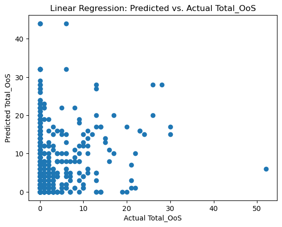

```python
#Revisamos con un plot:
plt.scatter(y_test5, y_pred5)
plt.title('Linear Regression: Predicted vs. Actual Total_OoS')
plt.xlabel('Actual Total_OoS')
plt.ylabel('Predicted Total_OoS')
plt.show()
```

Se realizan muchas menos predicciones aunque también hay menos erróneas.

Por tanto tenemos la opción de usar un SVM con el uso de una pequeña muestra y más precisión o un Decision Tree con todos los datos pero poca precisión. Pero la conclusión general es que la cantidad de valores 0 en Total_OoS ha desequilibrado las predicciones de los modelos, incluso a pesar de utilizar resampling.

## PREDICCIONES

```python
from sklearn.tree import DecisionTreeRegressor
from sklearn.model_selection import train_test_split
from sklearn.metrics import mean_squared_error

# Nuevo dataframe
X4 = df_product_cat[['Total_Sales', 'Total_Delivered', 'Cost_price', 'Sell_price', 'Margin',
                              'Month_3', 'Month_4', 'Month_5', 'Month_6', 'Month_7', 'Month_8', 'Month_9', 'Month_10',
                              'Product_Code_Natu408', 'Product_Code_Dome206', 'Product_Code_Dome427',
                              'Product_Code_Natu079', 'Product_Code_Brit627', 'Product_Code_Natu969',
                              'Product_Code_Dome164', 'Product_Code_Natu122', 'Product_Code_Brit700',
                              'Product_Code_Dome213', 'Product_Code_Inte404', 'Product_Code_Dome363',
                              'Product_Code_Dome762', 'Product_Code_Dome459', 'Product_Code_Natu723',
                              'Product_Code_Inte327', 'Product_Code_Dome615', 'Product_Code_Dome797',
                              'Product_Code_Dome527', 'Product_Code_Brit555', 'Product_Code_Natu461',
                              'Product_Code_Dome104',
                              'SIZE_85', 'SIZE_142', 'SIZE_190', 'SIZE_317', 'SIZE_283', 'SIZE_125', 'SIZE_114', 'SIZE_481']].copy()

# Variable Objetivo
y4 = df_product_cat[['Total_OoS']].copy()
```

```python
from sklearn.linear_model import LogisticRegression

# Lista de columnas para prediccion (incluyendo Month_3 a Month_10)

df_product_OoS_selected = X4.copy()

columns_for_prediction = [col for col in df_product_OoS_selected.columns if col != 'Month_11']
```

```python
# Separamos features para training
X_train6 = df_product_OoS_selected[columns_for_prediction]

# Creamos dataframe vacío para la columna predicho 'Month_11'
df_with_predicted_month_11 = df_product_OoS_selected.copy()

# Creamos y ajustamos un modelo de regresión logística
model = LogisticRegression()
model.fit(X_train6, df_product_OoS_selected['Month_10'])

# Predecimos los valores de mes 'Month_11'
predicted_month_11 = model.predict(X_train6)

# Asignamos los modelos predichos a la columna 'Month_11'
df_with_predicted_month_11['Month_11'] = predicted_month_11

# Mostramos el df
print(df_with_predicted_month_11)
```

```
        Total_Sales  Total_Delivered  Cost_price  Sell_price  Margin  Month_3  \
0                 8                0       40.30       48.70    8.40        0
1                 2                0       42.57       48.79    6.22        1
2                 2                0       42.06       50.45    8.39        0
3                 1                0       64.40       77.77   13.37        0
4                 2                0       40.30       48.70    8.40        0
...             ...              ...         ...         ...     ...      ...
380122            0                0       16.45       22.35    5.90        0
380123            0                0       22.30       27.30    5.00        0
380124            0                0       58.57       65.50    6.93        0
380125            0                0       20.57       29.50    8.93        0
380126            0                0       18.56       23.75    5.19        0

        Month_4  Month_5  Month_6  Month_7  ...  Product_Code_Dome104  \
0             0        0        0        0  ...                     0
```

[output cut: 38 more lines]

```python
df_with_predicted_month_11.columns
```

```
Index(['Total_Sales', 'Total_Delivered', 'Cost_price', 'Sell_price', 'Margin',
       'Month_3', 'Month_4', 'Month_5', 'Month_6', 'Month_7', 'Month_8',
       'Month_9', 'Month_10', 'Product_Code_Natu408', 'Product_Code_Dome206',
       'Product_Code_Dome427', 'Product_Code_Natu079', 'Product_Code_Brit627',
       'Product_Code_Natu969', 'Product_Code_Dome164', 'Product_Code_Natu122',
       'Product_Code_Brit700', 'Product_Code_Dome213', 'Product_Code_Inte404',
       'Product_Code_Dome363', 'Product_Code_Dome762', 'Product_Code_Dome459',
       'Product_Code_Natu723', 'Product_Code_Inte327', 'Product_Code_Dome615',
       'Product_Code_Dome797', 'Product_Code_Dome527', 'Product_Code_Brit555',
       'Product_Code_Natu461', 'Product_Code_Dome104', 'SIZE_85', 'SIZE_142',
       'SIZE_190', 'SIZE_317', 'SIZE_283', 'SIZE_125', 'SIZE_114', 'SIZE_481',
       'Month_11'],
      dtype='object')
```

```python
#Filtramos los valores para Month_11

df_with_predicted_month_11 = df_with_predicted_month_11[df_with_predicted_month_11['Month_11'] == 1]
```

```python
df_with_predicted_month_11.head(20)
```

|  | Total_Sales | Total_Delivered | Cost_price | Sell_price | Margin | Month_3 | Month_4 | Month_5 | Month_6 | Month_7 | ... | Product_Code_Dome104 | SIZE_85 | SIZE_142 | SIZE_190 | SIZE_317 | SIZE_283 | SIZE_125 | SIZE_114 | SIZE_481 | Month_11 |
| --- | --- | --- | --- | --- | --- | --- | --- | --- | --- | --- | --- | --- | --- | --- | --- | --- | --- | --- | --- | --- | --- |
| 25 | 3 | 0 | 52.03 | 56.00 | 3.97 | 0 | 0 | 0 | 0 | 0 | ... | 0 | 1 | 0 | 0 | 0 | 0 | 0 | 0 | 0 | 1 |
| 34 | 1 | 0 | 10.30 | 12.50 | 2.20 | 0 | 0 | 0 | 0 | 0 | ... | 0 | 0 | 1 | 0 | 0 | 0 | 0 | 0 | 0 | 1 |
| 54 | 3 | 0 | 47.58 | 56.49 | 8.91 | 0 | 0 | 0 | 0 | 0 | ... | 0 | 1 | 0 | 0 | 0 | 0 | 0 | 0 | 0 | 1 |
| 61 | 5 | 0 | 18.56 | 23.75 | 5.19 | 0 | 0 | 0 | 0 | 0 | ... | 0 | 1 | 0 | 0 | 0 | 0 | 0 | 0 | 0 | 1 |
| 63 | 1 | 0 | 27.40 | 32.00 | 4.60 | 0 | 0 | 0 | 0 | 0 | ... | 0 | 0 | 0 | 0 | 0 | 0 | 0 | 0 | 0 | 1 |
| 82 | 1 | 0 | 49.07 | 60.00 | 10.93 | 0 | 0 | 0 | 0 | 0 | ... | 0 | 1 | 0 | 0 | 0 | 0 | 0 | 0 | 0 | 1 |
| 91 | 3 | 0 | 35.41 | 43.50 | 8.09 | 0 | 0 | 0 | 0 | 0 | ... | 0 | 0 | 0 | 0 | 0 | 0 | 0 | 1 | 0 | 1 |
| 107 | 1 | 0 | 60.20 | 74.30 | 14.10 | 0 | 0 | 0 | 0 | 0 | ... | 0 | 1 | 0 | 0 | 0 | 0 | 0 | 0 | 0 | 1 |
| 108 | 1 | 0 | 45.90 | 50.99 | 5.09 | 0 | 0 | 0 | 0 | 0 | ... | 0 | 0 | 0 | 0 | 0 | 0 | 0 | 0 | 0 | 1 |
| 116 | 1 | 0 | 20.57 | 29.50 | 8.93 | 0 | 0 | 0 | 0 | 0 | ... | 0 | 0 | 0 | 0 | 0 | 0 | 0 | 0 | 0 | 1 |
| 124 | 2 | 0 | 17.38 | 25.40 | 8.02 | 0 | 0 | 0 | 0 | 0 | ... | 0 | 0 | 0 | 1 | 0 | 0 | 0 | 0 | 0 | 1 |
| 140 | 2 | 0 | 12.25 | 15.25 | 3.00 | 0 | 0 | 0 | 0 | 0 | ... | 0 | 1 | 0 | 0 | 0 | 0 | 0 | 0 | 0 | 1 |
| 177 | 3 | 0 | 18.56 | 23.75 | 5.19 | 0 | 0 | 0 | 0 | 0 | ... | 0 | 1 | 0 | 0 | 0 | 0 | 0 | 0 | 0 | 1 |
| 178 | 4 | 0 | 47.58 | 56.49 | 8.91 | 0 | 0 | 0 | 0 | 0 | ... | 0 | 1 | 0 | 0 | 0 | 0 | 0 | 0 | 0 | 1 |
| 187 | 1 | 0 | 15.38 | 18.45 | 3.07 | 0 | 0 | 0 | 0 | 0 | ... | 0 | 0 | 1 | 0 | 0 | 0 | 0 | 0 | 0 | 1 |
| 189 | 2 | 0 | 52.03 | 56.00 | 3.97 | 0 | 0 | 0 | 0 | 0 | ... | 0 | 1 | 0 | 0 | 0 | 0 | 0 | 0 | 0 | 1 |
| 193 | 3 | 0 | 17.38 | 25.40 | 8.02 | 0 | 0 | 0 | 0 | 0 | ... | 0 | 0 | 0 | 1 | 0 | 0 | 0 | 0 | 0 | 1 |
| 194 | 2 | 0 | 6.20 | 8.20 | 2.00 | 0 | 0 | 0 | 0 | 0 | ... | 0 | 0 | 0 | 0 | 1 | 0 | 0 | 0 | 0 | 1 |
| 202 | 2 | 0 | 47.58 | 56.49 | 8.91 | 0 | 0 | 0 | 0 | 0 | ... | 0 | 1 | 0 | 0 | 0 | 0 | 0 | 0 | 0 | 1 |
| 203 | 1 | 0 | 6.20 | 8.20 | 2.00 | 0 | 0 | 0 | 0 | 0 | ... | 0 | 0 | 0 | 0 | 1 | 0 | 0 | 0 | 0 | 1 |

20 rows × 44 columns

```python
#Quitamos columnas Month excepto Month_11

df_with_predicted_month_11.drop(['Month_3','Month_4','Month_5','Month_6','Month_7','Month_8','Month_9', 'Month_10'], axis=1, inplace=True)
```

```python
df_with_predicted_month_11.head()
```

|  | Total_Sales | Total_Delivered | Cost_price | Sell_price | Margin | Product_Code_Natu408 | Product_Code_Dome206 | Product_Code_Dome427 | Product_Code_Natu079 | Product_Code_Brit627 | ... | Product_Code_Dome104 | SIZE_85 | SIZE_142 | SIZE_190 | SIZE_317 | SIZE_283 | SIZE_125 | SIZE_114 | SIZE_481 | Month_11 |
| --- | --- | --- | --- | --- | --- | --- | --- | --- | --- | --- | --- | --- | --- | --- | --- | --- | --- | --- | --- | --- | --- |
| 25 | 3 | 0 | 52.03 | 56.00 | 3.97 | 0 | 0 | 0 | 0 | 0 | ... | 0 | 1 | 0 | 0 | 0 | 0 | 0 | 0 | 0 | 1 |
| 34 | 1 | 0 | 10.30 | 12.50 | 2.20 | 0 | 0 | 0 | 0 | 0 | ... | 0 | 0 | 1 | 0 | 0 | 0 | 0 | 0 | 0 | 1 |
| 54 | 3 | 0 | 47.58 | 56.49 | 8.91 | 1 | 0 | 0 | 0 | 0 | ... | 0 | 1 | 0 | 0 | 0 | 0 | 0 | 0 | 0 | 1 |
| 61 | 5 | 0 | 18.56 | 23.75 | 5.19 | 0 | 0 | 1 | 0 | 0 | ... | 0 | 1 | 0 | 0 | 0 | 0 | 0 | 0 | 0 | 1 |
| 63 | 1 | 0 | 27.40 | 32.00 | 4.60 | 0 | 0 | 0 | 0 | 0 | ... | 0 | 0 | 0 | 0 | 0 | 0 | 0 | 0 | 0 | 1 |

5 rows × 36 columns

```python
from sqlalchemy import create_engine
import pyodbc

# Detalles de conexión
server = 'DESKTOP-VUJ9ETK\\SQLEXPRESS'
database = 'TFM_EnriqueRocho'
driver = '{SQL Server}'
trusted_connection = 'yes'

# String de conexión
conn_str = f'DRIVER={driver};SERVER={server};DATABASE={database};Trusted_Connection={trusted_connection};'

# Conexión con pyodbc
conn = pyodbc.connect(conn_str)

# Creción de SQLAlchemy engine usando la conexión
engine = create_engine(f'mssql+pyodbc://', creator=lambda: conn)

# Cambiamos el nombre de la tabla
table_name = 'Prediccion_Rotura'

# Subimos el DataFrame a SQL Server
df_with_predicted_month_11.to_sql(table_name, engine, index=False, if_exists='replace')

print("DataFrame uploaded to SQL Server successfully!")
```

```
DataFrame uploaded to SQL Server successfully!
```